# MAT 105 - Introduction to Statistics: Statistics for Social Justice

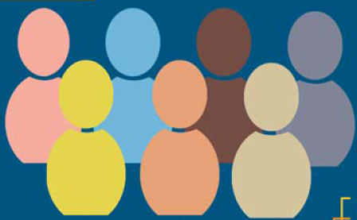

# Course Information

## Meeting Times

| Course Location | Meeting Days | Time |
| --- | --- | --- |
| Watson 132 | Tuesdays & Thursdays | 1:40-2:55pm |

## Instructor Information

| Instructor Information | Office Location | Hours |
| --- | --- | --- |
| Dr. Che Smith | Main Office Watson 283 | MW: 10-11 |
| chsmith1@davidson.edu (704) 894-2377 | Data CATS, drop in hours Hurt Hub, Room 212 | MWF: 1-4pm TR: 3:30-5pm |

## Syllabus

The course syllabus can be found [here](https://mat105.drchesmith.com/syllabus.html) .

# Schedule

### Week 1

**Topics**

- Course Overview
- Introduction to Statistics & Data

**Readings**

- OpenIntro Chapter 1

**Assignments**

- [Course intro survey]
- [Tutorial: Install R and RStudio]
- [Tutorial: Intro to R and Data]
- [Homework 1, Due 1/23]

### Week 2

**Topics**

- Introduction to R and R Studio
- Summarizing and Visualizing data

**Readings**

- OpenIntro Chapter 2

### Week 3

**Topics**

- Introduction to Probability

**Readings**

- OpenIntro Chapter 3

### Week 4

**Topics**

- Probability distributions
- Random variables

**Readings**

- OpenIntro Chapter 4

### Week 5

**Topics**

- Foundations of statistical inference
- Confidence Intervals

**Readings**

- OpenIntro Chapter 5

### Week 6

**Topics**

- Midterm 1 Review & Exam

### Week 7

**Topics**

- Hypothesis Testing

### Week 8

**Spring Break - NO CLASS**

### Week 9

**Topics**

- Sample size & power
- Data simulation

### Week 10

**Topics**

- Paired data
- Difference between means

### Week 11

**Topics**

- Midterm 2 Review
- Midterm 2

### Week 12

**Topics**

- Exploratory data analysis

### Week 13

**Topics**

- Inference for numerical data

**Readings**

- OpenIntro Chapter 7

### Week 14

**Topics**

- Simple Linear Regression
- Multiple Linear Regression

**Readings**

- OpenIntro Chapter 8
- OpenIntro Chapters 9.1-9.4

### Week 15

**Topics**

- Inference for categorical data
- Logistic Regression

**Readings**

- OpenIntro Chapter 6
- OpenIntro Chapter 9.5

### Week 16

**Topics**

- Statistical Study Design
- Predictive Inference

### Week 17

**Topics**

- Statistical Computing
- Final Exam Review

# Resource Guide

## Tutorials

Start here! [Install R and RStudio](https://mat105.drchesmith.com/tutorial1_Install.html)

## Create an RStudio Cloud account

https://rstudio.cloud

This work is licensed under a [Creative Commons Attribution 4.0 International License](http://creativecommons.org/licenses/by/4.0/).